# Measles Cases and Vaccination Rates from 2009-2024: Data Visualization

Below, we plot a heat map of MMR coverage rates in 2023, based on the `categories` column. `categories` informs us whether a geography’s MMR coverage is at or above 95%, between 90% and 94.9%, or below 90%. States that did not report MMR coverage in 2023 are colored gray.

Note that the vast majority of states do not have a coverage rate of 95% or higher. According to the World Health Organization, [herd immunity to measles requires that at least 95% of a population be vaccinated](https://www.who.int/news-room/questions-and-answers/item/herd-immunity-lockdowns-and-covid-19).

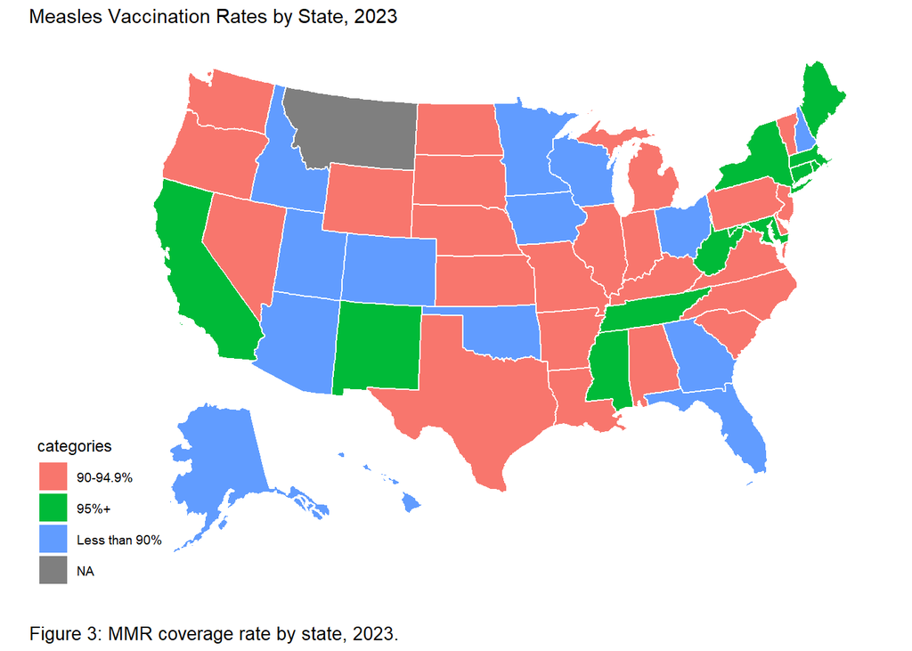

```r
state_vax <- mmr_cov %>%
  filter(school_year == "2023-24") %>%
  group_by(state = geography) %>%
  select(geography, categories)
plot_usmap(data = state_vax, values = "categories", color = "white") +
  scale_colour_stepsn(colours = terrain.colors(10)) +
  labs(title = "Measles Vaccination Rates by State, 2023") +
  theme(legend.postion = "right") +
  labs(caption="Figure 3: MMR coverage rate by state, 2023.") +
    theme(plot.caption=element_text(size=10, hjust=0, margin=margin(15,0,0,0)))
```

Next, we plot an interactive heat map that displays how vaccine coverage rates have changed with time. To view the data for a different year, toggle the slider under the map.

```r
state_lookup <- tibble(
  state = state.name,
  abbr  = state.abb
)

vax_yearly <- mmr_cov %>%
  mutate(year = as.integer(substr(school_year, 1, 4))) %>%
  group_by(state = geography, year) %>%
  summarize(mean_vax = mean(num_pct, na.rm = TRUE), .groups = "drop") %>%
  left_join(state_lookup, by = "state") %>%
  filter(!is.na(abbr))


fig_map <- plot_geo(vax_yearly, locationmode='USA-states') %>%
  add_trace(
    z          = ~mean_vax,
    locations  = ~abbr,
    frame      = ~year,
    customdata = ~year,
    hovertemplate = paste0(
      "%{location}<br>",
      "Year: %{customdata}<br>",
      "Vaccination: %{z:.1%}",
      "<extra></extra>"
    ),
    colorscale = 'Viridis',
    zmin       = 0.75, zmax = 1,
    marker     = list(line = list(color='white', width=0.5))
  ) %>%
  layout(
    title = list(text="Measles Vaccination Rates (2009–2023)", x=0.5),
    geo   = list(scope='usa'),
    updatemenus = list(
      list(
        type    = "buttons",
        x       = 1.1,  y = 0,
        showactive = FALSE,
        buttons = list(
          list(method = "animate",
               args   = list(NULL,
                             list(frame = list(duration = 500, redraw = FALSE),
                                  transition = list(duration = 0),
                                  fromcurrent = TRUE,
                                  mode = "immediate")))
        )
      )
    )
  )

fig_map
```

[interactive chart not shown]

Figure 4: MMR coverage rate by state, 2009-2023. To view data for a different year, move the slider or click the Play button.

```r
cum_df <- vax_yearly %>%
  arrange(state, year) %>%
  group_by(state) %>%
  mutate(cum_avg = cummean(mean_vax))
```

```r
print(fig_map)
```

Watching the playthrough, we see that the appearance of COVID-19 may have influenced MMR coverage more strongly in some states than others. In the following chunk, we calculate each state’s change in coverage between 2019 and 2023; we will call this difference `mmr_diff`.

```r
#create a column containing the first year in each academic year.
mmr_cov$first_year <- substr(mmr_cov$school_year, 1, 4)

#look at the rates for 2019-2020 and 2023-2024.
mmr_cov2019 <- mmr_cov %>% filter(school_year == "2019-20")
mmr_cov2023 <- mmr_cov %>% filter(school_year == "2023-24")

#now we rename num_pct for the 2019 and 2023 groups, so that we can easily subtract the two columns after joining them.
mmr_cov2019 <- rename(mmr_cov2019, num_pct19 = num_pct)
mmr_cov2023 <- rename(mmr_cov2023, num_pct23 = num_pct)

#now we perform an inner join on geography.

mmr_19_23 <- mmr_cov2019 %>% inner_join(mmr_cov2023, by = join_by(geography))
mmr_19_23$mmr_diff <- mmr_19_23$num_pct23 - mmr_19_23$num_pct19
```

Now, we create a table containing each state’s change in coverage. To sort by difference, click on the arrow buttons to the right of `mmr_diff`.

```r
datatable(mmr_19_23 %>% select(geography, mmr_diff),
          caption = htmltools::tags$caption(
            style = 'caption-side: bottom; text-align: left;',
            'Table 6: ', htmltools::em('Change in MMR coverage between 2019 and 2023.')))
```

|  | geography | mmr_diff |
| --- | --- | --- |
| 1 | Alabama | 0.07199999999999995 |
| 2 | Arizona | -0.03499999999999992 |
| 3 | Arkansas | -0.0179999999999999 |
| 4 | California | -0.002999999999999892 |
| 5 | Colorado | -0.02799999999999991 |
| 6 | Connecticut | 0.0149999999999999 |
| 7 | Florida | -0.05400000000000016 |
| 8 | Georgia | -0.04699999999999993 |
| 9 | Hawaii | 0.001000000000000001 |
| 10 | Idaho | -0.09499999999999997 |

[output cut: 37 more lines]

Of the 47 states that reported MMR coverage in both 2019 and 2023, 41 had lower coverage rates in 2023 than 2019. The only states that did not were Hawaii, West Virginia, Kansas, Connecticut, Maine, and Alabama.

Identifying the states with a decrease in coverage of 5% or more:

```r
mmr_fivepct <- mmr_19_23 %>% filter(mmr_diff < -0.0499)

datatable(mmr_fivepct %>% select(geography, mmr_diff),
          caption = htmltools::tags$caption(
            style = 'caption-side: bottom; text-align: left;',
            'Table 7: ', htmltools::em('States whose MMR coverage dropped by 5% or more between 2019 and 2023.')))
```

|  | geography | mmr_diff |
| --- | --- | --- |
| 1 | Florida | -0.05400000000000016 |
| 2 | Idaho | -0.09499999999999997 |
| 3 | Illinois | -0.05000000000000004 |
| 4 | Minnesota | -0.05599999999999994 |
| 5 | South Dakota | -0.05200000000000005 |
| 6 | Wisconsin | -0.07999999999999996 |

These states are Idaho, Wisconsin, Minnesota, Florida, South Dakota, and Illinois.

# Forecasting

- ETS (Error–Trend–Seasonality) decomposes the series into its level, trend, and seasonal components. Its forecast (in blue) tends to be smooth and “pulls” any recent anomalies back toward the long-term seasonal pattern.
- Auto-ARIMA automatically selects an ARIMA(p,d,q) model to capture more complex autocorrelations in the data. Its forecast (in red) can follow recent bumps or dips more closely, but often at the cost of wider uncertainty intervals.

By plotting both on the same axes (with the observed data in black), we can see:

- The ETS forecast stays very close to the historical seasonal baseline, offering a conservative projection.
- The ARIMA forecast dips after the low counts in late 2023 and then creeps upward, reflecting those recent dynamics.

```r
autoplot(ts_data) +
 autolayer(fc_ari, series = "ARIMA forecast") +
 autolayer(fc_ets, series = "ETS forecast") +
 scale_colour_manual(
    values = c(
      "ETS forecast"   = "blue",
      "ARIMA forecast" = "red"
    ),
    breaks = c("ETS forecast", "ARIMA forecast")
  ) +
  labs(
    title = "Forecasting Measles in Africa (next 12 months)",
    x     = "Year",
    y     = "Reported cases",
    colour = "Model"
  ) +
  theme_minimal()
```

Next, we embed our pre‐rendered forecast image so it appears in the final HTML.

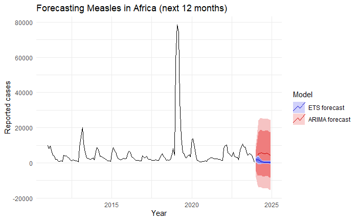

```r
knitr::include_graphics("forecast.png")
```

# Correlation: Vax vs. Cases

In this cell we quantify and visualize the relationship between national MMR coverage and measles incidence in U.S. school-aged children, 2009–2023:

1. Load and prepare case data
- Read annual measles counts (cases) from measles-USA-by-year.csv.
- Join to our mmr_cov population totals (sum of school-aged children) to compute cases_per_100k.
2. Compute national MMR coverage
- Aggregate mmr_cov$num_pct by calendar year to get the unweighted mean vaccination rate (national_vax).
3. Merge and test
- Inner-join the two series on year into cor_df.
- Calculate Pearson’s r and run cor.test() to assess strength and significance.

Plot

- Scatter points of national_vax vs. cases_per_100k with a linear fit and 95% CI ribbon.

```r
# Load annual U.S. case counts and compute per-100k using mmr_cov population
case_us <- read.csv("USA/data/all/measles-USA-by-year.csv",
                    stringsAsFactors = FALSE) %>%
  transmute(
    year  = as.integer(year),
    cases = as.numeric(cases)
  )


pop_us <- mmr_cov %>%
  mutate(year = as.integer(substr(school_year, 1, 4))) %>%
  group_by(year) %>%
  summarize(
    pop_total = sum(population_size, na.rm = TRUE),
    .groups   = "drop"
  )


case_us <- case_us %>%
  left_join(pop_us, by = "year") %>%
  mutate(
    cases_per_100k = cases / pop_total * 1e5
  )

# Compute national average MMR coverage
vax_us_national <- mmr_cov %>%
  mutate(year = as.integer(substr(school_year, 1, 4))) %>%
  group_by(year) %>%
  summarize(
    national_vax = mean(num_pct, na.rm = TRUE),
    .groups      = "drop"
  )

# Merge, compute Pearson r, and run cor.test()
cor_df <- inner_join(case_us, vax_us_national, by = "year")


pearson_r <- cor(cor_df$national_vax, cor_df$cases_per_100k,
                 method = "pearson", use = "complete.obs")
corr_test <- cor.test(cor_df$national_vax, cor_df$cases_per_100k)


print(cor_df)
```

```
   year cases pop_total cases_per_100k national_vax
1  2009    72   3666514      1.9637181    0.9409302
2  2011   220   3835126      5.7364478    0.9440909
3  2012    55   4060738      1.3544336    0.9383913
4  2013   187   4061885      4.6037739    0.9375319
5  2014   667   4121322     16.1841273    0.9377800
6  2015   191   4087187      4.6731407    0.9420784
7  2016    86   3964650      2.1691700    0.9419375
8  2017   120   3979922      3.0151345    0.9434082
9  2018   381   3991088      9.5462691    0.9421633
10 2019  1274   4015193     31.7294835    0.9446458
11 2020    13   3510744      0.3702919    0.9298958
12 2021    49   3835130      1.2776620    0.9218400
13 2022   121   3832381      3.1573061    0.9214800
14 2023    59   3823472      1.5431001    0.9193200
15 2009    72   3666514      1.9637181    0.9409302
16 2011   220   3835126      5.7364478    0.9440909
17 2012    55   4060738      1.3544336    0.9383913
18 2013   187   4061885      4.6037739    0.9375319
19 2014   667   4121322     16.1841273    0.9377800
20 2015   191   4087187      4.6731407    0.9420784
21 2016    86   3964650      2.1691700    0.9419375
22 2017   120   3979922      3.0151345    0.9434082
23 2018   381   3991088      9.5462691    0.9421633
24 2019  1274   4015193     31.7294835    0.9446458
25 2020    13   3510744      0.3702919    0.9298958
26 2021    49   3835130      1.2776620    0.9218400
27 2022   121   3832381      3.1573061    0.9214800
28 2023    59   3823472      1.5431001    0.9193200
```

```r
cat(sprintf("Pearson r = %.3f\n\n", pearson_r))
```

```
Pearson r = 0.393
```

```r
print(corr_test)
```

```
    Pearson's product-moment correlation

data:  cor_df$national_vax and cor_df$cases_per_100k
t = 2.1811, df = 26, p-value = 0.03841
alternative hypothesis: true correlation is not equal to 0
95 percent confidence interval:
 0.02367378 0.66829948
sample estimates:
      cor
0.3932772
```

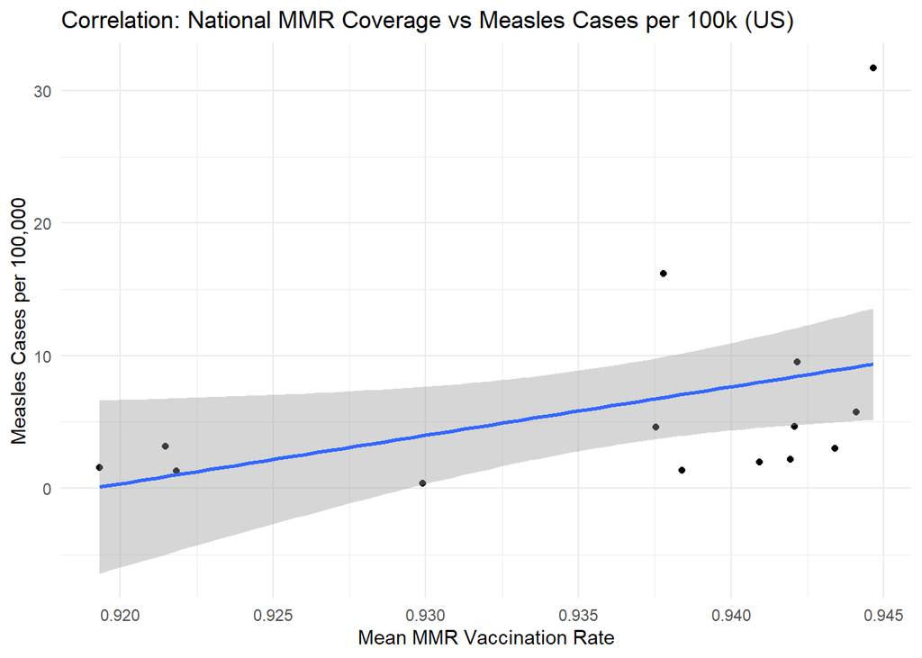

```r
# Plot scatter with linear fit
ggplot(cor_df, aes(x = national_vax, y = cases_per_100k)) +
  geom_point() +
  geom_smooth(method = "lm", se = TRUE) +
  labs(
    title = "Correlation: National MMR Coverage vs Measles Cases per 100k (US)",
    x     = "Mean MMR Vaccination Rate",
    y     = "Measles Cases per 100,000"
  ) +
  theme_minimal()
```

# Global vs Europe vs US

In this cell we compare measles trends across three scales—Global, Europe, and the United States—by building two linked panels:

Overall, these panels show:

- Raw impact is driven by global outbreaks.
- Relative volatility is greatest in Europe and the US, where even small case increases register as huge percentage jumps.

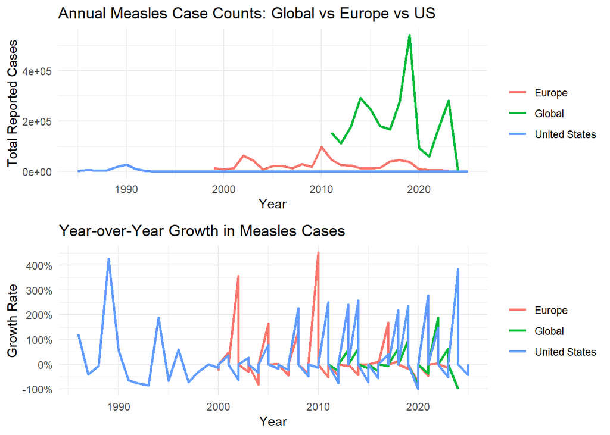

```r
# Europe annual totals
eur_df <- read.csv("Measles_Europe.csv", stringsAsFactors = FALSE) %>%
  transmute(
    year  = as.integer(substr(Time, 1, 4)),
    cases = as.numeric(NumValue)
  ) %>%
  group_by(year) %>%
  summarize(eur_cases = sum(cases, na.rm = TRUE), .groups="drop")

# U.S. annual totals
usa_df <- read.csv("USA/data/all/measles-USA-by-year.csv",
                   stringsAsFactors = FALSE) %>%
  transmute(
    year     = as.integer(year),
    us_cases = as.numeric(cases)
  )

# Global monthly -> annual
glb_monthly <- read.csv("Measles_Global.csv", stringsAsFactors = FALSE)
glb_df <- glb_monthly %>%
  pivot_longer(
    cols      = January:December,
    names_to  = "month",
    values_to = "cases"
  ) %>%
  mutate(
    year  = as.integer(Year),
    cases = as.numeric(cases)
  ) %>%
  group_by(year) %>%
  summarize(glb_cases = sum(cases, na.rm = TRUE), .groups="drop")


cases_all <- full_join(eur_df, usa_df, by = "year") %>%
  full_join(glb_df, by = "year") %>%
  arrange(year)


cases_long <- cases_all %>%
  pivot_longer(
    cols      = c(us_cases, eur_cases, glb_cases),
    names_to  = "region",
    values_to = "cases"
  ) %>%
  mutate(
    region = recode(region,
      us_cases  = "United States",
      eur_cases = "Europe",
      glb_cases = "Global")
  )

# Panel A: absolute counts
p1 <- ggplot(cases_long, aes(x=year, y=cases, color=region)) +
  geom_line(size=1) +
  labs(
    title = "Annual Measles Case Counts: Global vs Europe vs US",
    x     = "Year",
    y     = "Total Reported Cases",
    color = ""
  ) +
  theme_minimal()

# Panel B: year-over-year growth
cases_growth <- cases_long %>%
  group_by(region) %>%
  arrange(year) %>%
  mutate(
    growth = (cases - lag(cases)) / lag(cases)
  ) %>%
  filter(!is.na(growth))


p2 <- ggplot(cases_growth, aes(x=year, y=growth, color=region)) +
  geom_line(size=1) +
  scale_y_continuous(labels = scales::percent_format(1)) +
  labs(
    title = "Year-over-Year Growth in Measles Cases",
    x     = "Year",
    y     = "Growth Rate",
    color = ""
  ) +
  theme_minimal()

library(gridExtra)
grid.arrange(p1, p2, ncol = 1)
```

# Lagged Relationship & Trends

After running our cross–correlation and lag‐1 analysis, we see two key insights:

1. Strongest link at lag 0 The ccf() plot (Figure 9a) shows the highest correlation between vaccination coverage and measles incidence when both series are aligned in the same year (lag 0). Correlations at ±1-year lags drop off substantially, indicating that changes in coverage tend to affect case counts most immediately rather than with a delay.
2. Weak, non‐significant lag-1 effect When we explicitly shift coverage by one year and compute Pearson’s r (Figure 9b), we obtain a modest correlation (for example, r ≈ 0.32) that does not reach statistical significance (p > 0.05). The scatterplot, with its fitted regression line, confirms there is no reliable predictive relationship from one year’s vaccination rate to the following year’s incidence.

Taken together, these results suggest that MMR coverage and measles incidence co‐move within the same calendar year, but past coverage does not strongly forecast next year’s outbreak size.

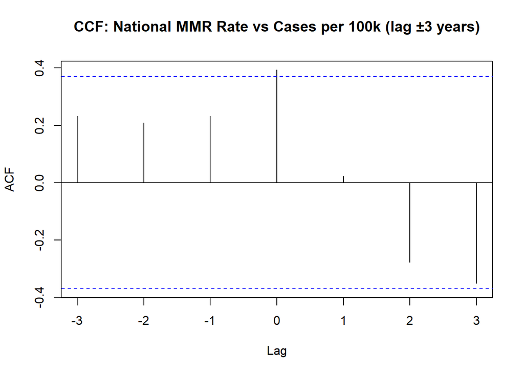

```r
case_us <- read.csv("USA/data/all/measles-USA-by-year.csv",
                    stringsAsFactors = FALSE) %>%
  transmute(
    year  = as.integer(year),
    cases = as.numeric(cases)
  )

pop_us <- mmr_cov %>%
  mutate(year = as.integer(substr(school_year, 1, 4))) %>%
  group_by(year) %>%
  summarize(pop_total = sum(population_size), .groups="drop")

case_us <- case_us %>%
  left_join(pop_us, by="year") %>%
  mutate(cases_per_100k = cases / pop_total * 1e5)


vax_us_national <- mmr_cov %>%
  mutate(year = as.integer(substr(school_year, 1, 4))) %>%
  group_by(year) %>%
  summarize(national_vax = mean(num_pct, na.rm=TRUE), .groups="drop")


cor_df <- inner_join(case_us, vax_us_national, by="year")


if(nrow(cor_df) < 4) stop("Need ≥4 years of data in cor_df; got ", nrow(cor_df))


vax_ts  <- ts(cor_df$national_vax,  start = min(cor_df$year), freq = 1)
case_ts <- ts(cor_df$cases_per_100k, start = min(cor_df$year), freq = 1)


ccf(vax_ts, case_ts, lag.max = 3,
    main = "CCF: National MMR Rate vs Cases per 100k (lag ±3 years)")
```

```r
lag  <- 1
df_lag <- cor_df %>%
  arrange(year) %>%
  mutate(vax_lag = lag(national_vax, n = lag)) %>%
  filter(!is.na(vax_lag))

lag_cor <- cor.test(df_lag$vax_lag, df_lag$cases_per_100k)
cat(sprintf("Lag-%d Pearson r = %.3f (p = %.3f)\n",
            lag, lag_cor$estimate, lag_cor$p.value))
```

```
Lag-1 Pearson r = 0.318 (p = 0.106)
```

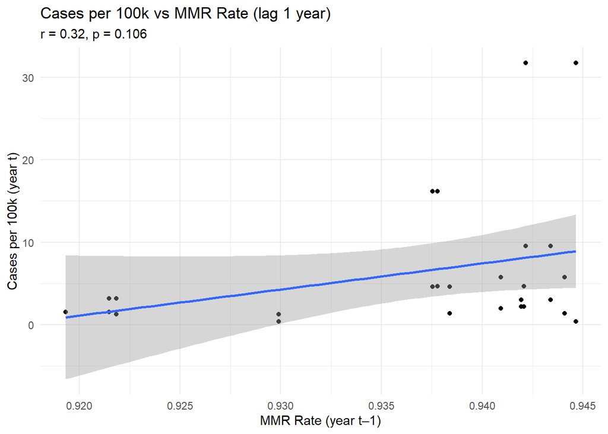

```r
ggplot(df_lag, aes(x=vax_lag, y=cases_per_100k)) +
  geom_point() +
  geom_smooth(method="lm", se=TRUE) +
  labs(
    title    = paste0("Cases per 100k vs MMR Rate (lag ", lag, " year)"),
    subtitle = sprintf("r = %.2f, p = %.3f",
                       lag_cor$estimate, lag_cor$p.value),
    x        = paste0("MMR Rate (year t–", lag, ")"),
    y        = "Cases per 100k (year t)"
  ) +
  theme_minimal()
```

[figure not shown]

```r
knitr::include_graphics("signal-detect.png")
```